# File Input/Output

EE1021 Programming for Engineers - Lecture 10

Basri Erdogan

## Lecture Goals

1. Explain how files are organized: **paths, extensions, text vs binary content**
2. Open and close files with `open(filename, mode)` and the modes `'r'`, `'w'`, `'a'`, `'r+'`, `'b'`
3. Read files with `read()`, `readline()`, `readlines()`, and line-by-line iteration
4. Write to files with `write()` and automate closing with the **`with` statement**
5. Parse text using `split()`, `strip()`, and `rstrip()`, and process **CSV files** with the `csv` module
6. Handle missing files with `try`/`except` and work with **binary files** and portable paths

# Part 1: Working with Files

## Last Week / Today

**Last week**

- Object-oriented programming

**Today**

- File input/output

## Files and Folders

- A computer **file** is a resource for storing information; a “digital” document.
- Files are organized in **folders** (= directories).
- Every file has an address (**path**) in the computer’s file system.
  - Example: `C:\Desktop\ta5_code\test_file.txt`
- The file’s **extension** represents its content type (`txt`, `exe`, `mp3`, `avi`, `jpg`).
- **Text files** are composed of a sequence of characters.
- **Binary files** store a sequence of bytes representing any type of information (not necessarily encoding for characters).

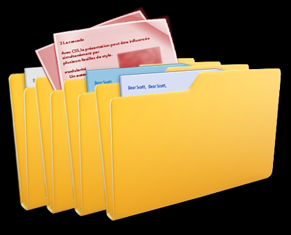

## Text Files

- Text files are composed of **lines** of text.
- Every line is composed of a sequence of characters.
- The last character on every line is the special ‘new line’ character (`'\n'`), usually hidden by most text editors.

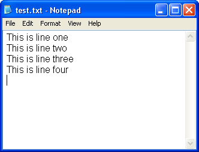

## Opening a Connection to a File

- `open()` returns a **file object**.
- Most commonly used with two arguments: `open(filename, mode)`
  - `filename`: an address of a file.
  - `mode`:
    - `'w'` - write - overwrites (“deletes”) prior data
    - `'r'` - read
    - `'a'` - append - adds at end of prior data
    - `'r+'` - opens the file to read and write
    - `'b'` appended to the mode opens the file in binary mode

## Reading a Whole File

```python
>>> f = open('test_file.txt', 'r')  # returns a file object
>>> s = f.read()  # reads the entire file, returns its contents as a string
>>> print(s)
This is a file
>>> f.close()     # releases the file lock, frees resources
```

In case the file is located in a different directory, use the full path:

```python
>>> f = open('C:/Users/Desktop/ta5_code/test_file.txt', 'r')
>>> f
<open file 'C:/Users/Desktop/ta5_code/test_file.txt', mode 'r' at 0x00000000026F95D0>
>>> f.read()
'This is a file'
>>> f.close()
```

## Reading Line by Line

The `for` loop is used to read line after line from a file object:

```python
>>> f = open('test_file_2.txt', 'r')
>>> for line in f:
...     print(line)
this is line 1

this is line 2

the end
>>> f.close()
```

Storing read lines as a list of strings:

```python
f = open('test_file_2.txt', 'r')
lines = []
for line in f:
    lines.append(line)
f.close()
```

Or… use:

```python
lines = f.readlines()
```

## Functions for Reading from a File

- `f.read()` - reads an entire file as a single string
- `f.readline()` - reads the next line as a string
- `f.readlines()` - reads all remaining lines as a list of strings
- Iterating a file:

```python
for line in f:
    ...
```

## Remarks

- Reading advances the file position, so we cannot `read()` twice from the same file, or loop twice (with `for`) over the same file.
- Remember to close the file using `f.close()` to free up resources.
- In a string, `'\n'` represents the new line character:

```python
>>> a_line = 'this is a line\n'
>>> a_line
'this is a line\n'
>>> print(a_line + 'more text')
this is a line
more text
```

## Parsing a Text File - `split`

- Reading a text file means breaking every line into fields based on some predefined format.
- The `split` method splits a string into tokens using a delimiter, and returns a list of strings.

```python
s = "Ankara,Istanbul,Izmir,Bursa"
cities = s.split(',')
for city in cities:
    print(city)
```

```
Ankara
Istanbul
Izmir
Bursa
```

- If a delimiter is not specified, the string is split into words separated by a sequence of whitespaces.

## Parsing a Text File - `strip` & `rstrip`

Use `strip` to remove unwanted characters from both sides of the string:

```python
>>> '    spacious   '.strip()
'spacious'
>>> 'www.example.com'.strip('cmowz.')
'example'
```

The string method `rstrip()` can be used to get rid of trailing newlines:

```python
>>> lines
['this is line 1\n', 'this is line 2\n', 'the end']
>>> for i in range(len(lines)):
...     lines[i] = lines[i].rstrip()
>>> lines
['this is line 1', 'this is line 2', 'the end']
```

# Part 2: Writing to Files

## File Output: Writing to a File

Use `f.write(str)`:

```python
# open a file (or create it if no such file exists)
f = open('test_file_3.txt', 'w')
f.write("This is a test")

# newline
f.write('\n')

# to write a non-string object, first convert it to a string
tpl = ('string', 40)
f.write(str(tpl))

# flush data to the file and close it, unlock file, free resources
f.close()
```

Check the result:

```python
>>> f = open('test_file_3.txt', 'r')
>>> print(f.read())
This is a test
('string', 40)
```

## The `with` Keyword

- The keyword `with` allows us to automate the closing of a file.
- Modify your code as follows:

```python
with open('test_file_3.txt', 'w') as file:
    file.write("this is a test\n")
```

- This implementation ensures the file is closed once the code inside the `with` block is executed.

## Example: Writing a List of Numbers to a Text File

```python
my_list = [i**2 for i in range(1, 11)]  # list comprehension!
# generates a list of the squares of the numbers 1 - 10

f = open("output.txt", "w")
for item in my_list:
    f.write(str(item) + "\n")
f.close()
```

# Part 3: CSV Files

## CSV Files

- CSV stands for **“comma separated values”**.
- Let’s have a CSV file named `students.csv` that looks like:

```
Mert,Electronic
Ayse,Computer
Halil,Industrial
Hamit,Electronic
```

- Create a new program:

```python
with open("students.csv") as file:
    for line in file:
        row = line.rstrip().split(",")
        print(f"{row[0]} is in {row[1]}")
```

```
Mert is in Electronic
Ayse is in Computer
Halil is in Industrial
Hamit is in Electronic
```

## The `csv` Module

- **Standard library**: Python includes a built-in module called `csv` specifically for reading and writing CSV files.
- It is more robust than manually splitting strings with `line.split(',')`.
- **Handles complexity**: it automatically handles edge cases, such as fields that contain commas (e.g., `"Doe, John"`), quotes, or newlines.

```python
import csv

# open the file using the csv module
with open('students.csv', 'r') as file:
    reader = csv.reader(file)
    for row in reader:
        # 'row' is automatically converted to a list of strings
        print(row)
# Output: ['Mert', 'Electronic'] ...
```

## Converting CSV Content into Dictionaries

**Dictionary implementation**

```python
import csv

students = []
with open("students.csv") as file:
    lines = csv.reader(file)
    for name, major in lines:
        students.append({"name": name,
                         "major": major})

for student in students:
    print(f"{student['name']} is in {student['major']}")
```

**Sorted version**

```python
import csv

students = []
with open("students.csv") as file:
    lines = csv.reader(file)
    for name, major in lines:
        students.append({"name": name,
                         "major": major})

def get_name(student):
    return student["name"]

for student in sorted(students, key=get_name):
    print(f"{student['name']} is in {student['major']}")
```

## Lambda Expressions (Anonymous Functions)

- The expression below creates a **function object**:

```python
lambda parameters: expression
```

- The unnamed object behaves like a function object defined with:

```python
def some_function(parameters):
    return expression
```

## Sorting with a Lambda

```python
import csv

students = []
with open("students.csv") as file:
    lines = csv.reader(file)
    for name, major in lines:
        students.append({"name": name, "major": major})

for student in sorted(students, key=lambda s: s["name"]):
    print(f"{student['name']} is in {student['major']}")
```

Output:

```
Ayse is in Computer
Halil is in Industrial
Hamit is in Electronic
Mert is in Electronic
```

# Part 4: Robust File Handling

## Handling File Errors

- **The problem**: what if the file you try to open doesn’t exist? The program will crash with a `FileNotFoundError`.
- **The solution**: use `try` and `except` blocks to handle errors gracefully.
- **Best practice**: always anticipate potential issues when working with external files (missing files, permission issues).

```python
filename = "missing_file.txt"
try:
    # try to execute this block of code
    with open(filename, 'r') as f:
        content = f.read()
        print(content)
except FileNotFoundError:
    # if the file is not found, run this block instead of crashing
    print(f"Error: The file '{filename}' was not found.")
```

## Text vs. Binary Files

- **Text files** (`.txt`, `.csv`, `.py`): store data as a sequence of characters. The computer encodes these characters (e.g., UTF-8, ASCII).
- **Binary files** (`.dat`, `.jpg`, `.mp3`, `.exe`): store data as a sequence of bytes (0s and 1s). There is no character encoding.
- **Why it matters**: if you try to open an image in text mode (`'r'`), Python will try to decode the bytes as text and crash or give garbage output.
- Modes:
  - `'rb'`: read binary
  - `'wb'`: write binary

## Writing into a Binary File

When working with binary files, we read and write `bytes` objects, not strings.

```python
# We want to generate a voltage ramp from 0V to 5V.
# In our 8-bit system, that means numbers from 0 to 255.

# Create a list of integers representing voltage levels.
# This represents one 'cycle' of a sawtooth wave.
signal_points = [0, 50, 100, 150, 200, 255, 0, 50, 100, 150, 200, 255]

# Convert the list of integers into raw bytes
binary_data = bytes(signal_points)
print(f"Signal ready: {list(binary_data)}")

# Save to a binary file ('wb') to simulate loading it into the device memory
with open("waveform.dat", "wb") as f:
    f.write(binary_data)

print("Waveform saved to waveform.dat")
```

## Reading from a Binary File

Let’s write a script that reads the binary file and “plots” it to the screen using simple text bars.

```python
# Read the raw binary data from the 'instrument'
with open("waveform.dat", "rb") as f:
    data = f.read()

print("--- REPLAYING SIGNAL ---")

# Iterate through every byte (voltage sample)
for sample in data:
    # 'sample' is automatically an integer (0-255)
    # Calculate real voltage (scale 0-255 to 0V-5V)
    real_voltage = (sample / 255) * 5.0
    # Create a simple visual bar graph
    bar_graph = "#" * (sample // 10)
    print(f"Data: {sample:3d} | Voltage: {real_voltage:.2f}V | {bar_graph}")
```

## Absolute vs. Relative Paths

- **Absolute path**: the full, unique address of a file starting from the root of the drive.
  - Analogy: a GPS coordinate (e.g., “41.0082 N, 28.9784 E”).
  - Example: `C:\Users\Student\Project\data.txt` (Windows) or `/home/student/project/data.txt` (Mac/Linux).
- **Relative path**: the path to a file relative to the script’s current location (current working directory).
  - Analogy: directions from where you are standing (e.g., “go down the hall and take the second door”).
  - Example: `data.txt` (same folder) or `folder/data.txt` (subfolder).
- **Key takeaway**: relative paths make your code portable. If you move your project folder to another computer, absolute paths will break, but relative paths will still work.

## Absolute vs. Relative Paths: Example

```python
import os

# Absolute path (hardcoded - avoid this!)
# This will crash if you move the script to another computer
abs_path = "C:/Users/Basri/Documents/Project/data.txt"

# Relative path (portable - preferred)
# Looks for 'data.txt' in the same folder as the script
rel_path = "data.txt"

print(f"Current Working Directory: {os.getcwd()}")

# Best practice: build paths dynamically.
# This works on Windows, Mac, and Linux automatically.
full_path = os.path.join(os.getcwd(), "data.txt")
```

## Summary

- `open(filename, mode)` returns a file object; modes `'r'`, `'w'`, `'a'`, `'r+'`, and binary `'b'` control access.
- Read with `read()`, `readline()`, `readlines()`, or by iterating the file object line by line.
- Write strings with `write()`; convert non-string objects with `str()` first.
- The `with` statement closes files automatically - prefer it over manual `close()`.
- Parse lines with `split()`, clean them with `strip()`/`rstrip()`, and use the `csv` module for real CSV data.
- Wrap file access in `try`/`except FileNotFoundError`, use binary modes for non-text data, and prefer relative paths for portability.